# Benford App - Raport

Filimon Ioana-Andreea, Furdui Vlad-Rares, Mihai Andrei-Alexandru

02.02.2023

Legea lui Benford :
$$P(d)=lg (d+1)
-lg(d)=lg(\frac{d+1}{d})=lg(1+\frac {1}{d}), d\in\{1..9\}$$

## Aplicativitatea legii lui Benford

Una dintre aplicabilitățile legii lui Benford este cea de a identifica posibiliele fraude la nivelul statisticilor, iar cum review-urile constau, într-o mare parte, într-unul dintre cele mai puternice puncte de referință în convingerea utilizatorului de a-și cumpăra o aplicație sau un joc, această lege poate verifica veridicitatea acestora. Astfel, sunt introduse numărul de recenzii pentru aplicațiile de pe Google Play, dar și pentru jocurile de pe cea mai ulilizată platformă în acest sens, Steam, date pe care generarea graficului se bazează în generarea acestuia.

## Construcția aplicației

Inițial, am ales **layout-ul aplicației** : un *panel* care conține un *selector* pentru tipul de date (practic, **selectăm experimentul pe care dorim să îl realizăm**) și un *slider* prin care user-ul selectează *mărimea de referință*.

Pentru fiecare experiment realizat se generează un *grafic* și un *tabel* cu datele experimentului, care se pot sorta în funcție de mai multe categorii și se pot filtra cu ajutorul unui SearchBar.

Header-ul aplicaței este format dintr-un **navbarPage** care conține titlul aplicației și câte un **tabPanel** pentru experimentul curent. Am afișat legea lui Benford printr-un **uiInput** care primeste ca parametru formula legii.

Sidebar-ul este creeat cu ajutorul unui **sideBarPanel** care conține un *meniu de tip dropdown* pentru a selecta tipul de date și un *sliderInput* pentru a selecta mărimea de referință dintr-un interval predefinit.

În final, **mainPanel-ul** conține 2 taburi : **graficul** pentru experimentul curent, dar și **tabelul** datelor.Graficele funcțiilor sunt realizate prin intermediul librăriei **ggplot2**, iar aplicațiea web, cât și tema acesteia sunt realizate cu ajutorul librăriilor **shiny**, respectiv **shinythemes**.

```r
library(shiny)
library(shinythemes)
library(ggplot2)

ui <- fluidPage( theme = shinytheme("united"),

      navbarPage("Benford App",

                tabPanel("Recenzii",
                    h3("Legea lui Benford"),
                    uiOutput('formula'),

                    h4("Aplicații și Jocuri"),

                    textOutput("text1"),
                    textOutput("text2"),


                      sidebarLayout(

                      sidebarPanel(

                      selectInput("tip", "Alege tipul de date:",
                              choices=c('aplicatii', 'jocuri')),





                      sliderInput("n", "Marime de referinta", min = 0, max =20000, value = 7000),

                      hr(),

                      helpText("Sursa date:"),
                      conditionalPanel(condition = "input.tip == 'aplicatii' ",
     tags$a(href="https://www.kaggle.com/datasets/lava18/google-play-store-apps", "Google Play Store Apps")),
                      conditionalPanel(condition = "input.tip == 'jocuri' ",
   tags$a(href="https://www.kaggle.com/datasets/rahuldabholkar/steam-pc-games", "PC Games")),
                                       ),


                      mainPanel(

                      tabsetPanel(
                      tabPanel("Grafic", plotOutput("date")),
                      tabPanel("Vizualizare date tabel", DT::dataTableOutput("mytable") )
                                         )
                                       )

                                     )
                            ),


     helpText("Proiect realizat de Filimon Ioana-Andreea, Furdui Vlad-Rares, Mihai Andrei-Alexandru (241)")
                 )

)
```

PARTEA DE SERVER

Am definit funcția Benford, care preia un vector de rate si numarul de linii sau coloane din acele rate și extrage prima cifră din fiecare rată. Apoi calculeaza frecvența fiecărei cifre de la 1 la 9. Ulterior, funcția calculează procentul fiecărei cifre din totalul de aparitii al tuturor cifrelor și valorile standard ale lui Benford. La final, funcția formează un data frame cu numerele, valorile standard ale lui Benford și procentele calculate anterior și generează un grafic care compară aceste valori.

O scurtă explicație intuitivă a motivului pentru care o astfel de diferență în distribuție apare în „natură” (cu numărul „1” care apare mai frecvent, apoi, după aceea, numărul 2 și așa mai departe) ia în considerare faptul că, în numărarea acestuia, începe de la numărul 1 până la 9. Dacă restrângem câmpul doar la numerele de la 1 la 9 este clar că probabilitatea ca o cifră să înceapă cu 1 sau 2 sau 3 sau 9 trebuie să fie întotdeauna aceeași. Cu toate acestea, acolo unde numerele de la 1 la 20 sunt deja luate în considerare, vor exista mult mai multe numere începând cu cifra 1 (10 la 19). Dacă luați cele de la 1 la 30, veți avea multe începând cu 1, dar și cu 2. După cum se poate vedea cu ușurință, pentru a avea, de exemplu, numere care încep cu 9, trebuie mers foarte departe cu numerele.

Funcția **primaCifra** extrage prima cifră dintr-un număr x primit ca parametru.

În final, se formează un data frame din care se va genera graficul.

```r
server <- function(session,input,output) {

  output$text1<-renderText({
    "Una dintre aplicabilitățile legii lui Benford este cea de a identifica posibiliele fraude la nivelul statisticilor, iar cum review-urile constau, într-o mare parte, într-unul
    dintre cele mai puternice puncte de referință în convingerea utilizatorului de a-și cumpăra o aplicație sau un joc, această lege poate verifica veridicitatea acestora.
    "
  })
  output$text2<-renderText({
    "
    Astfel, sunt introduse numărul de recenzii pentru aplicațiile de pe Google Play, dar și pentru jocurile de pe cea mai ulilizată platformă în acest sens, Steam, date pe care
    generarea graficului se bazează în generarea acestuia.

    "
  })

  output$formula <- renderUI({
    withMathJax(

      helpText('$$P(d)=lg (d+1) -lg(d)=lg(\\frac{d+1}{d})=lg(1+\\frac {1}{d}), d\\in\\{1..9\\}$$')
    )
  })

  Benford<- function(rate, linii_coloana)
  {

    primaCifra<-function(x) as.numeric(substr(gsub('[0.]', '', x), 1, 1))

    frecv<-c(0,0,0,0,0,0,0,0,0)
    for (i in 1:linii_coloana)
    {
      cifra<-primaCifra(rate[i])
      frecv[cifra]<-frecv[cifra]+1
    }
    total<-sum(frecv)

    procent<-c(0,0,0,0,0,0,0,0,0)
    for (i in 1:9)
    {
      procent[i]<-frecv[i]/total

    }
    benford<-c(0,0,0,0,0,0,0,0,0)
    for (i in 1:9)
    {
      benford[i]<-log10(1+ 1/i)
    }

    frame3<-data.frame(
      numere=c("1","2", "3", "4", "5", "6", "7", "8", "9"),
      ben=benford,
      procente=procent
    )

    ggplot(data = frame3, aes(x = numere, group=1))+ geom_bar(aes(y = procente), stat = "identity", color=NA, fill="lightblue") + geom_line(aes(y = ben), stat = "identity", color="red")

  }


  output$date <- renderPlot({


    nume_csv<-paste(input$tip, ".csv", sep="")
    data1<-(read.csv(nume_csv, header=TRUE))

    if(nume_csv == "aplicatii.csv")
    tabel<- data.frame(
      Nume=data1$App,
      Rating=data1$Rating,
      Marime=data1$Size,
      Reviews=data1$Reviews,
      Instalari=data1$Installs
      )


    if(nume_csv == "jocuri.csv")

      tabel<- data.frame(
        Nume=data1$title,
        Pret=data1$price,
        Reviews=data1$Reviews,
        ProcentDeApreciere=data1$percent_positive
        )

    output$mytable = DT::renderDataTable({tabel})


    rate<-data1$Reviews

    linii_coloana<-input$n

    Benford(rate, linii_coloana)

  })



}
```

Acestea sunt graficul și datele pentru aplicații;

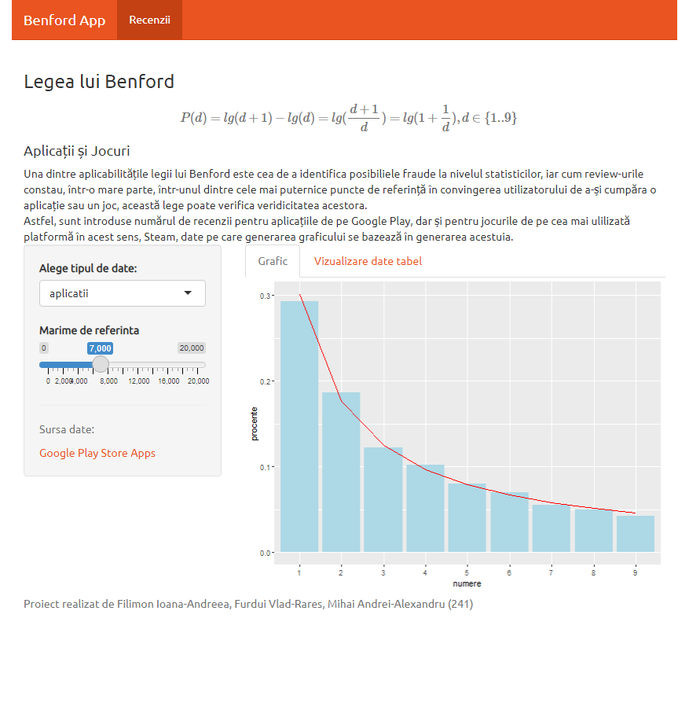

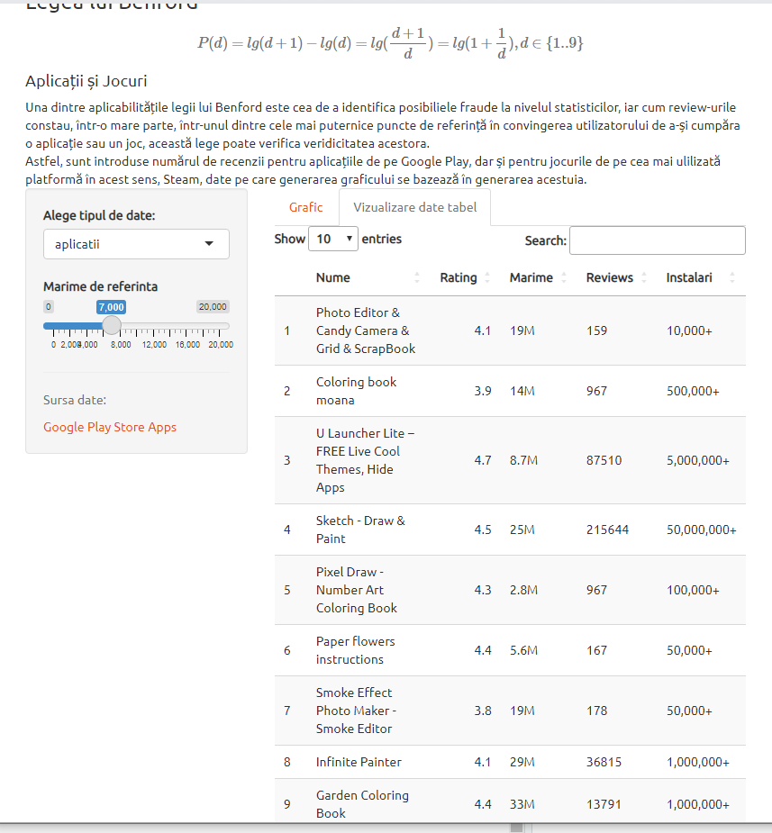

Acestea sunt graficul și datele pentru jocuri;

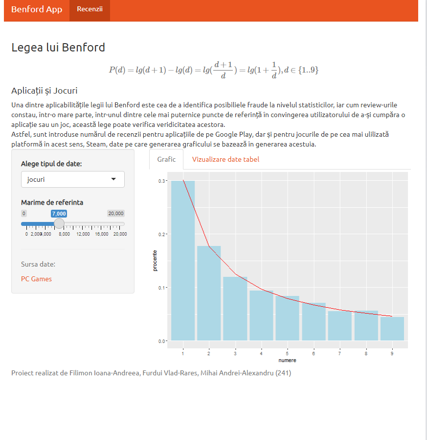

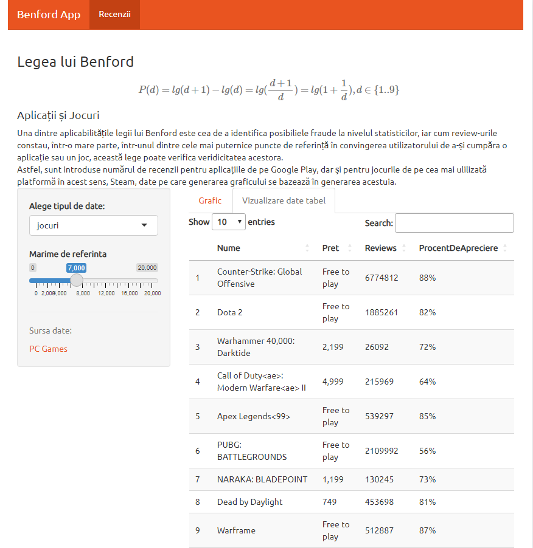